# Impact Evaluation Coding Sample

Kamran Ahmed

### Understanding the effects of womens’ representation in politics on economic development

I use a sample data on villages with female leadership from 2001 to 2015 for this analysis. The data include villages that never elected a female leader and villages that elected female leaders between 2005 and 2010. I define a village as “treated” in the year in which it first elects a female leader, and for every period thereafter. The data include variables village id, year, gross village product and female election year.

```r
df <- read.csv("sample_data.csv")
head(df)
```

|  | year | village_id | female_election_year | gross_village_product |
| --- | --- | --- | --- | --- |
| 1 | 2001 | 1 | 2005 | 31550.84 |
| 2 | 2002 | 1 | 2005 | 29309.80 |
| 3 | 2003 | 1 | 2005 | 30112.12 |
| 4 | 2004 | 1 | 2005 | 30359.09 |
| 5 | 2005 | 1 | 2005 | 33267.16 |
| 6 | 2006 | 1 | 2005 | 36256.35 |

a simple comparison of average economic productivity between villages with and without a female leader.

```r
# Simple regression
df %>%
  mutate(has_fem_leader = ifelse(!is.na(female_election_year), 1, 0)) %>%
  lm(gross_village_product ~ has_fem_leader, data = .) %>%
  stargazer(., header = FALSE, type = "text")
```

================================================== Dependent variable:  
—————————— gross_village_product  
————————————————– has_fem_leader 11,660.150***  
(47.327)

Constant 27,969.640***  
(25.000)

[output not shown]

I plot average GVP over time for villages that elected women in 2010. I also plot average pre-treatment and average post-treatment GVP on the same plot.

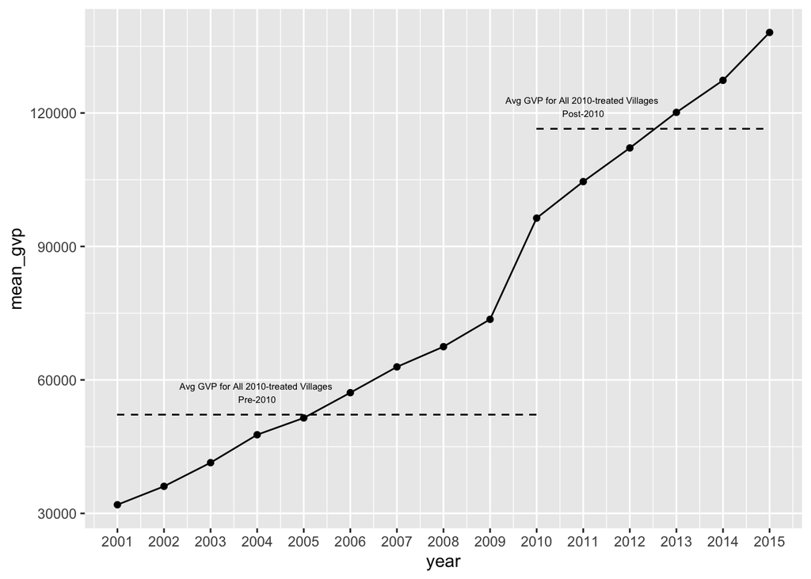

```r
# create mean GVP data for 2010 election villages
df_2010_summary <- df_2010 %>%
  group_by(year) %>%
  summarize(mean_gvp = mean(gross_village_product)) %>%
  ungroup()

# get averages for plot
mean_gvp_pre_2010 <- mean(df_2010$gross_village_product[df_2010$post ==0])
mean_gvp_post_2010 <- mean(df_2010$gross_village_product[df_2010$post ==1])


# make plot
  ggplot(df_2010_summary,
         aes(x = year, y = mean_gvp)) +
  geom_point() +
  geom_line() +
  geom_segment(aes(x = 2001,  xend = 2010, y = mean_gvp_pre_2010, yend = mean_gvp_pre_2010), data = NULL, linetype = 2) +
  geom_segment(aes(x = 2010, xend = 2015,  y = mean_gvp_post_2010, yend = mean_gvp_post_2010), data = NULL, linetype = 2) +
  annotate("text", x = 2004, y = mean_gvp_pre_2010 + 5000, label = "Avg GVP for All 2010-treated Villages \nPre-2010", size = 2) +
  annotate("text", x = 2011, y = mean_gvp_post_2010 + 5000, label = "Avg GVP for All 2010-treated Villages \nPost-2010", size = 2) +
  scale_x_continuous(breaks = seq(2001, 2015, 1))
```

Now we plot average economic productivity against time for villages that never elected a female leader and assess the viability of using these villages as a control group for the villages that elected a woman in 2010 and then we assess the viability of using the male-leader-only villages as a control group for the 2005 female leader villages.

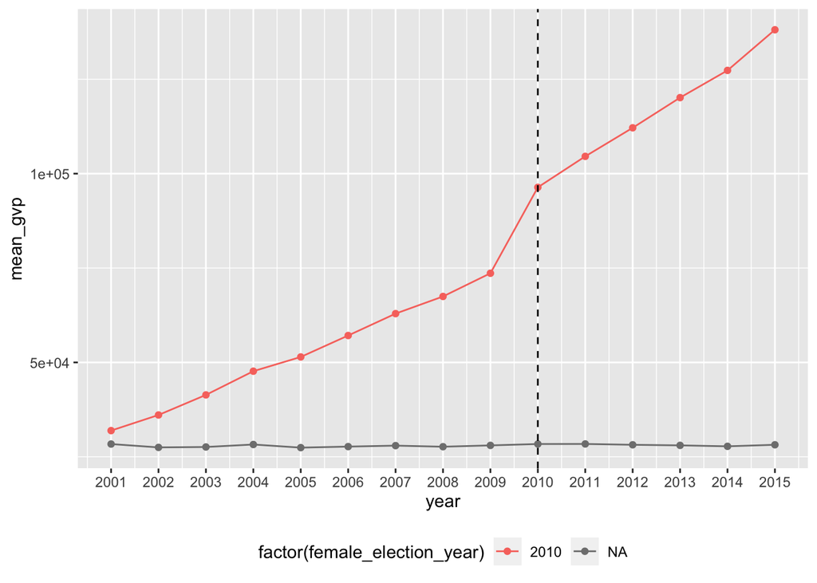

```r
df %>%
  filter(is.na(female_election_year) | female_election_year == "2010") %>%
  group_by(year, female_election_year) %>%
  summarize(mean_gvp = mean(gross_village_product),
            .groups = "keep") %>%
  ggplot(aes(year, mean_gvp,
             color = factor(female_election_year))) +
  geom_point() +
  geom_line() +
  geom_vline(aes(xintercept = 2010), linetype = 2) +
  scale_x_continuous(breaks=seq(2001, 2015, 1)) +
  theme(legend.position="bottom")
```

Villages that never elected a female leader are probably not a good control for 2010-treated villages. Through the graph, we can see that GVP was increasing in villages before treatment in 2010, and the slope is very different from the constant trend in the never-treated villages’ GVP. This could indicate that trends in GVP post-treatment also wouldn’t be parallel, in the absence of treatment.

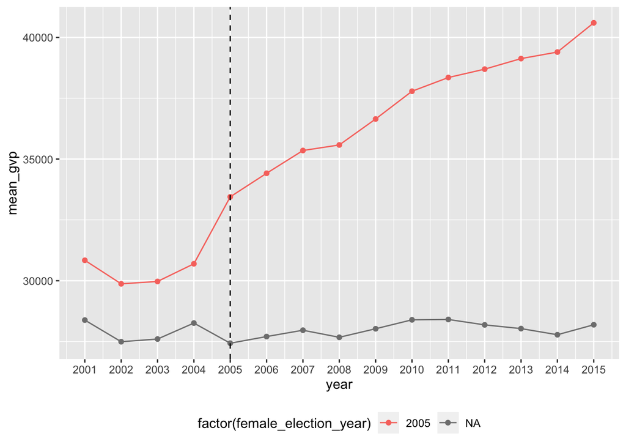

```r
df %>%
  filter(is.na(female_election_year) | female_election_year == "2005") %>%
  group_by(year, female_election_year) %>%
  summarize(mean_gvp = mean(gross_village_product),
            .groups = "keep") %>%
  ggplot(aes(year, mean_gvp,
             color = factor(female_election_year))) +
  geom_point() +
  geom_line() +
  geom_vline(aes(xintercept = 2005), linetype = 2) +
  scale_x_continuous(breaks=seq(2001, 2015, 1)) +
  theme(legend.position="bottom")
```

Here, we see that the pre-treatment trends for never-treated villages and 2005-treated villages are very similar. That may mean that never-treated villages may be a viable counter-factual for this particular set of treated villages.

Using just the male-leader-only villages and the 2005 female-electing villages, we estimate the causal impact of a female leader on economic productivity. First, we find a simple difference in means (rather than regression). Next, we use a simple regression (no fixed effects) and finally, fixed effects to control for common time shocks and time-invariant village characteristics

```r
df_2005 <- df %>%
  filter(female_election_year == 2005|is.na(female_election_year)) %>%
  mutate(D = case_when(female_election_year == 2005 & year >= 2005 ~ 1,
                       female_election_year == 2005 & year < 2005 ~ 0,
                       is.na(female_election_year) ~ 0,
                       TRUE ~ as.numeric(NA)),
         treat = ifelse(is.na(female_election_year), 0, 1),
         post = ifelse(year >= 2005, 1, 0))
```

```r
# simple comparison - DID
use.tab <- df_2005 %>%
  group_by(treat, post) %>%
  summarize(mean.use = mean(gross_village_product),
            .groups = "keep")
use.tab %>%
  kable()
```

| treat | post | mean.use |
| --- | --- | --- |
| 0 | 0 | 27935.52 |
| 0 | 1 | 27982.04 |
| 1 | 0 | 30345.18 |
| 1 | 1 | 37217.79 |

```r
# Calculate difference in difference (simple means)
(use.tab$mean.use[4] - use.tab$mean.use[3]) -
  (use.tab$mean.use[2] - use.tab$mean.use[1])
```

```
## [1] 6826.078
```

The impact of female leadership on gross village product, estimated by simply claculating the difference of means, is $6,826$.

```r
# Regression without fixed effects - both methods are equivalent
reg1 <- felm(gross_village_product ~ treat * post + treat + post|0|0|village_id, data = df_2005)
reg2 <- felm(gross_village_product ~ D + treat + post|0|0|village_id, data = df_2005)
stargazer(reg1, reg2, type = "text", header = FALSE)
```

============================================================== Dependent variable:  
—————————- gross_village_product  
(1) (2)  
————————————————————– D 6,826.078*** (15.439)

treat 2,409.666*** 2,409.666*** (12.686) (12.686)

post 46.525*** 46.525***  
(3.002) (3.002)

treat:post 6,826.078***  
(15.439)

Constant 27,935.520*** 27,935.520*** (3.103) (3.103)

[output not shown]

Now we plot average economic productivity over time, separately (but on the same graph) for villages that elected a female leader in each of the years from 2005 to 2010.

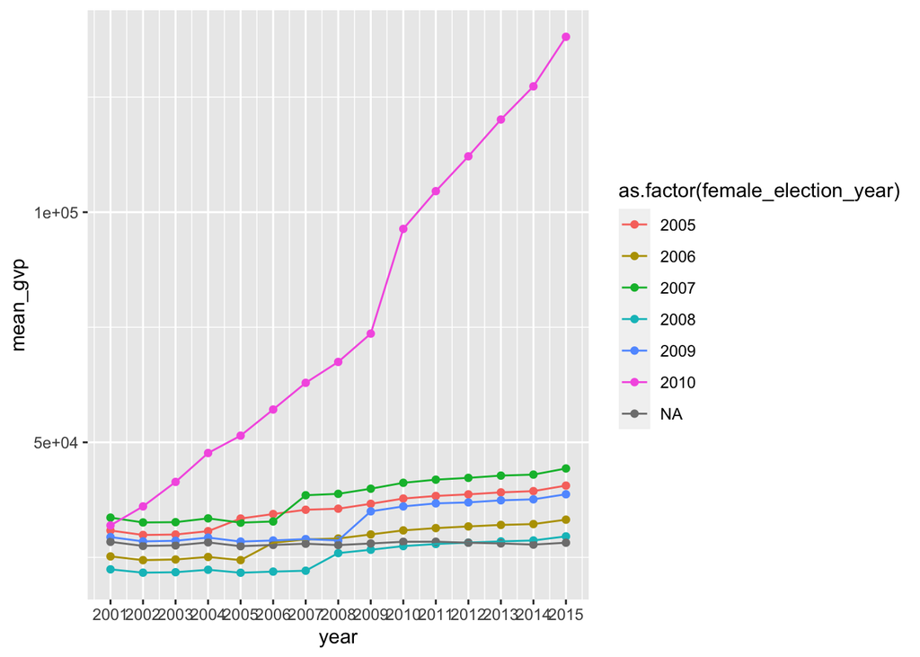

```r
df %>%
  group_by(female_election_year, year) %>%
  summarize(mean_gvp = mean(gross_village_product),
            .groups = "keep") %>%
  ggplot(aes(x = year, y = mean_gvp, color = as.factor(female_election_year))) +
  geom_point() +
  geom_line() +
  scale_x_continuous(breaks = seq(2001, 2015, 1))
```

We can see clearly from this plot, that the villages who elected female leadership in 2010 have shown a divergent pattern of GVP from other villages, and from the never-treated group (those villages that never elected female leadership). Therefore, they don’t form a fair comparison group, and common time fixed effect assumptions are likely to fail. Therefore, we drop these villages in our analysis and use the remaining villages to estimate a panel fixed effects regression to identify the causal effect of female leadership on economic productivity.

```r
df_es <- df %>%
  filter(female_election_year != 2010|is.na(female_election_year)) %>%
  mutate(D = case_when(!is.na(female_election_year) & year >= female_election_year ~ 1,
                       !is.na(female_election_year) & year < female_election_year ~ 0,
                       is.na(female_election_year) ~ 0,
                       TRUE ~ as.numeric(NA)))

fix <- felm(gross_village_product ~ D|village_id + year|0|village_id, data = df_es)
stargazer(fix, header = FALSE, type = "text")
```

=============================================== Dependent variable:  
————————— gross_village_product  
———————————————– D 6,705.237***  
(16.200)

Observations 307,545 R2 0.934 Adjusted R2 0.930 Residual Std. Error 919.743 (df = 287027) =============================================== Note: *p<0.1; **p<0.05;*** p<0.01

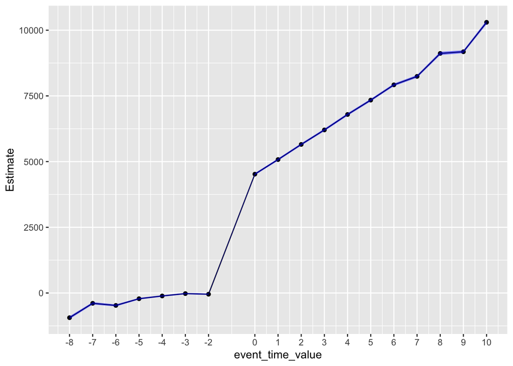

```r
res <- as.data.frame(summary(es)$coefficients)
res$low <- res$Estimate - qnorm(1 - 0.05/2)*res$`Cluster s.e.`
res$high <- res$Estimate + qnorm(1 - 0.05/2)*res$`Cluster s.e.`
res$event_time_value <- c(-8:-2, 0:10)

res %>%
  ggplot(aes(x = event_time_value, y = Estimate)) +
  geom_point() +
  geom_line() +
  geom_ribbon(aes(ymin = low, ymax = high), fill = "blue", alpha = .5) +
  scale_x_continuous(breaks = res$event_time_value)
```

From the results above ,the event study regression is potentially the most useful. First, the estimate has dropped set of villages who elected female leadership in 2010, which appear to be trending differently, and includes only the sets of villages that appear to be trending similarly over time. Compared to the 2005-treated regression, the sample is larger because we allowing treatments to happen at different points in time. One possible shortcoming with this event study design is bundled treatments - it may be the case that the female leadership election, even for the various cohorts that were treated in different years, coincides with other economic or policy reforms that would also influence GVP.